# Getting to know my audience

An example of literate programming

October 7, 2016

```r
# Load libraries
library(googlesheets)
library(dplyr);library(ggplot2)
library(knitr);library(xtable)
opts_chunk$set(warning=FALSE, message=FALSE, echo=FALSE, fig.align='center')
```

# Introduction

This report analyzes [survey data](https://goo.gl/forms/y7V2IvC60fEujjRf1) collected at the Emphasizing Reproducible Research by Teaching Data Analysis with R Presentation at the CELT 2016 Conference. After setting up proper authorization tokens, we connect directly to Google Sheets to download the data.

Looking at the raw data, we see that the names of the data frame are set to the question titles, which makes analysis very difficult to deal with. We rename these variable names something easier to manage.

# Description of the data set

## College

| AGR | BSS | BUS | CME | ECC | HFA | NS |
| --- | --- | --- | --- | --- | --- | --- |
| 2 | 5 | 2 | 1 | 1 | 2 | 4 |

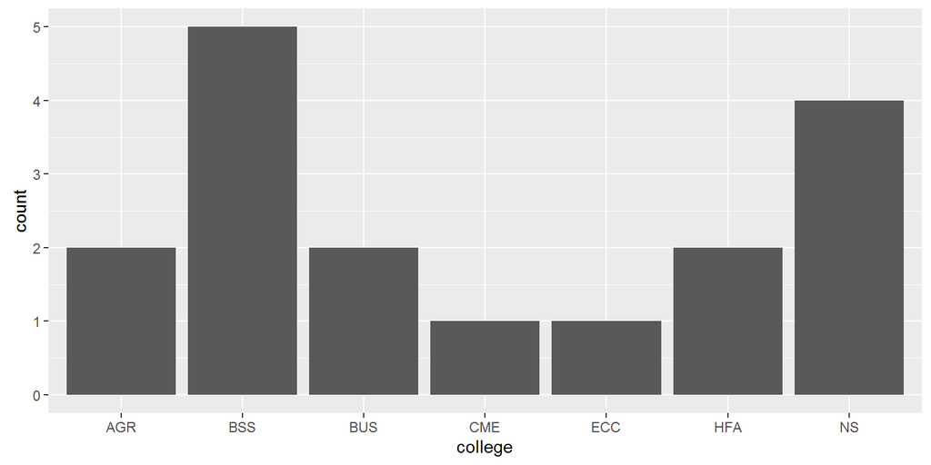

College Representation

## Usage of R

|  | No | Yes | Sum |
| --- | --- | --- | --- |
| No | 7 | 2 | 9 |
| Yes | 4 | 4 | 8 |
| Sum | 11 | 6 | 17 |

There are 10 (58.8%) people in the audience who use R for their teaching or research. Of the 6 who use it for research, 2 (33.3%) don’t use it for teaching.

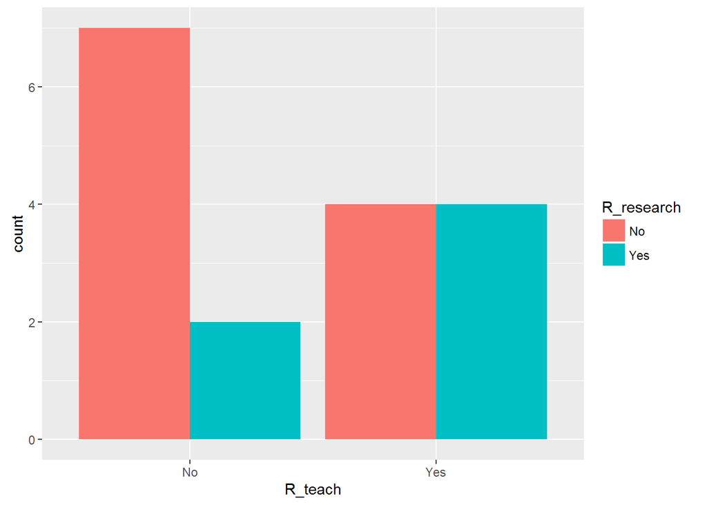

## Years teaching

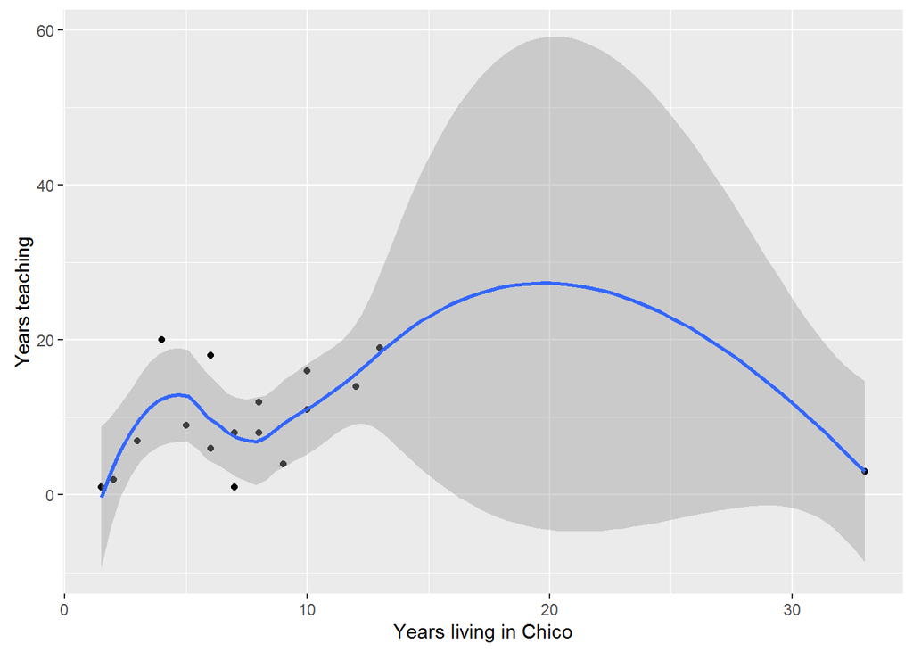

Does this relationship differ by college?

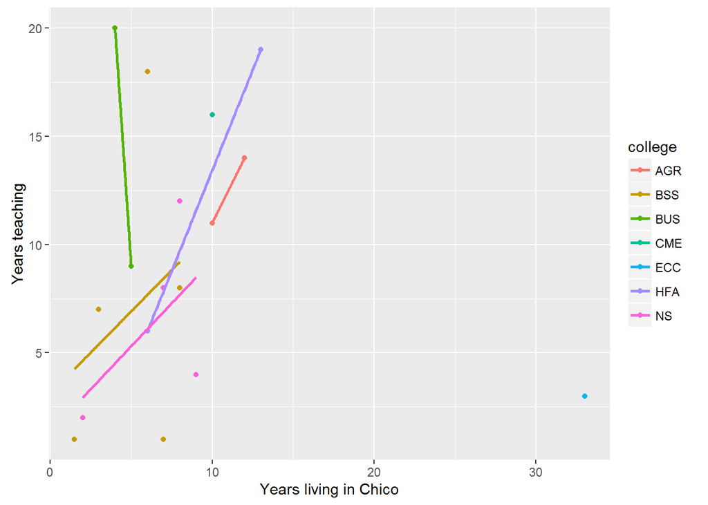

Now the big question: Is the use of R in research or teaching a relative new thing?

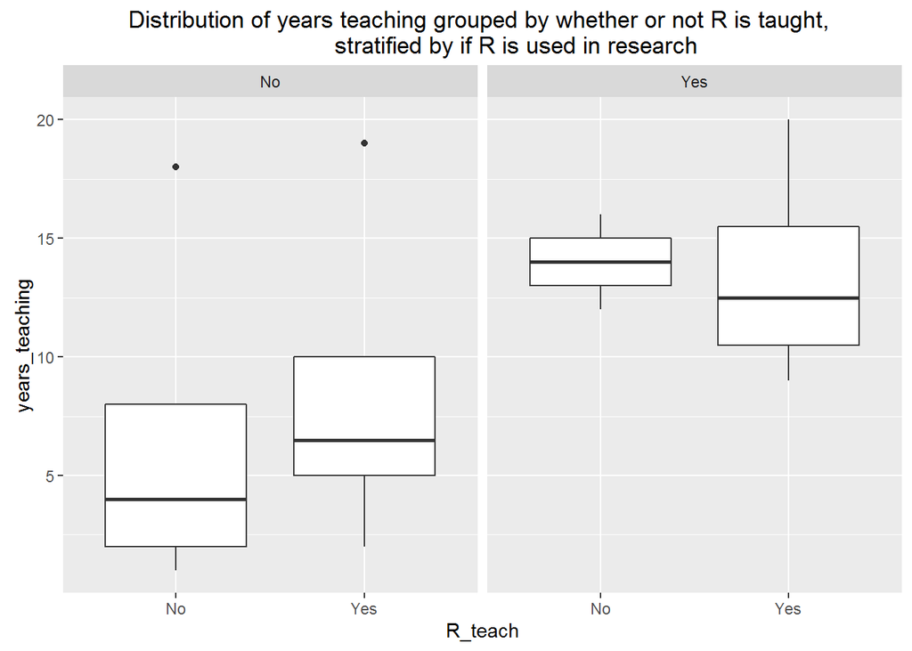

An ANOVA was used to test if there is a significant difference in the average years teaching for those who teach, or do research in R.

|  | Df | Sum Sq | Mean Sq | F value | Pr(>F) |
| --- | --- | --- | --- | --- | --- |
| R_teach | 1 | 40.99 | 40.99 | 1.25 | 0.28 |
| R_research | 1 | 138.89 | 138.89 | 4.23 | 0.06 |
| Residuals | 14 | 460.00 | 32.86 | NA | NA |